# Proyecto

Author

Cadena Paul

Published

June 10, 2026

# PROYECTO DE APRENDIZAJE DE MAQUINA

### IMPORTACION DE TODAS LAS LIBRERIAS SKLEARN, NLTK, PANDAS, ALTAIR

### EN ESTE PROYECTO SE TIENE UN DATAFRAME DE TWEETS UNA VARIABLE OBJETIVO TOXICITY_SCORE

### USAREMOS ESTA VARIABLE TARGET PARA HACER NUESTROS MODELOS,ETC

### LO PRIMERO SERA EL EDA DONDE NOS ADENTRAREMOS EN LOS DATOS DE ENTRADA Y PREPARARLOS

### SEGUNDO USAREMOS MODELOS NO SUPERVISADOS PARA HALLAR CLUSTERS USAREMOS KMEANS Y HAC PARA

### AGREGAR ALGUN VALOR EXTRA A LOS DATOS Y LUEGO PASAREMOS A REALIZAR LOS MODELOS DE CLASIFICACION ### Y REGRESION TODO ESTO JUNTO A OTRAS TECNICAS PARA OBSERVACION DE LOS DATOS

```python
import pandas as pd
import numpy as np
import nltk
from nltk.corpus import stopwords
from nltk.stem import WordNetLemmatizer
from nltk.tokenize import word_tokenize
from nltk import pos_tag
from nltk.corpus import wordnet
from sklearn.feature_extraction.text import TfidfVectorizer
from sklearn.cluster import KMeans, AgglomerativeClustering
from sklearn.preprocessing import StandardScaler
from sklearn.compose import ColumnTransformer
from sklearn.pipeline import Pipeline
from sklearn.metrics import silhouette_score, classification_report, confusion_matrix, ConfusionMatrixDisplay, roc_auc_score, roc_curve, auc, accuracy_score, precision_score, recall_score, f1_score
from sklearn.impute import SimpleImputer
from sklearn.preprocessing import OneHotEncoder
from sklearn.model_selection import train_test_split, GridSearchCV
from sklearn.neighbors import KNeighborsClassifier
from sklearn.ensemble import RandomForestClassifier, GradientBoostingClassifier
from scipy.cluster.hierarchy import dendrogram, linkage
import altair as alt
import matplotlib.pyplot as plt
import seaborn as sns

nltk.download('stopwords')
nltk.download('wordnet')
nltk.download('punkt')
nltk.download('averaged_perceptron_tagger')
```

```
True
```

### FUNCION PARA TRATAMIENTO DE TEXTO REDUCCION, LEMATIZACION

```python
lemmatizer = WordNetLemmatizer()

def get_wordnet_pos(treebank_tag):
    if treebank_tag.startswith('J'):
        return wordnet.ADJ
    elif treebank_tag.startswith('V'):
        return wordnet.VERB
    elif treebank_tag.startswith('N'):
        return wordnet.NOUN
    elif treebank_tag.startswith('R'):
        return wordnet.ADV
    else:
        return wordnet.NOUN

def preprocessing_document(doc):
    try:
        doc = str(doc).lower()
        tokens = word_tokenize(doc)
        tagged_tokens = pos_tag(tokens)
        filtered_tokens = [(word, pos) for (word, pos) in tagged_tokens if word.isalpha()]
        lemmatized_words = [lemmatizer.lemmatize(word, get_wordnet_pos(pos)) for word, pos in filtered_tokens]
        return " ".join(lemmatized_words)
    except:
        return ""
```

### IMPORTAMOS EL CSV DE NUEVOS TWEETS CON PANDAS

```python
url = "https://raw.githubusercontent.com/erickedu85/dataset/refs/heads/master/tweets/1500_tweets_con_toxicity.csv"
df = pd.read_csv(url)
```

## EDA

### BUSQUEDA DE COLUMNAS CON MAS DEL 70% DE FALTANTES, HASHTAGS TIENE

### DEMASIADAS FALTANTES, SE ELIMINARAN JUNTO A SENTIMENT Y SE USARA

### DF_CLEANED PARA ESTE PROCESO

```python
nan_percent = df.isna().mean() * 100
threshold_nan = 70
cols_to_drop = nan_percent[nan_percent > threshold_nan].index
df_cleaned = df.drop(columns=cols_to_drop)
df_cleaned = df_cleaned.drop(['hashtags', 'sentiment_polarity'], axis=1, errors='ignore')
```

### TRANSFORMACION DE VARIABLES FECHAS, DIA CREADO, FECHA CREACION DE CUENTAS Y SE CREAN COLUMNAS MAS ESPECIFICAS COMO DIAS CON LA CUENTA ,ETC

```python
df_cleaned['createdAt'] = pd.to_datetime(df_cleaned['createdAt'], errors='coerce')
df_cleaned['authorJoinDate'] = pd.to_datetime(df_cleaned['authorJoinDate'], errors='coerce')
df_cleaned['diaCreated'] = df_cleaned['createdAt'].dt.day
df_cleaned['diasDesdeCreacion'] = (pd.Timestamp.today() - df_cleaned['authorJoinDate']).dt.days
df_cleaned = df_cleaned.drop(['authorJoinDate', 'createdAt'], axis=1, errors='ignore')
```

### SE HABILITARA LA MANIPULACION DE DATOS

```python
alt.data_transformers.disable_max_rows()
```

```
DataTransformerRegistry.enable('default')
```

### BUSQUEDA COLUMNAS CATEGORICAS NUMERICAS PARA SU DEBIDO TRATAMIENTO

```python
numerical_columns = df_cleaned.select_dtypes('number').columns.tolist()
categorical_columns = df_cleaned.select_dtypes('object').columns.to_list()
categorical_columns_remove = ['content', 'authorName', 'authorUsername', 'Director', 'content_cleaned']
categorical_filtered = [col for col in categorical_columns if col not in categorical_columns_remove]

if 'toxicity_score' in numerical_columns:
    numerical_columns.remove('toxicity_score')
```

# GRAFICA DE NAN muestra valores nulos, vacios en el df

### SE OBSERVA VARIOS VALORES FALTANTES EN SE IMPUTARAN EN TOXICITY SCORE

```python
# Tomar una muestra para que el gráfico no sea tan pesado


# Crear DataFrame indicando dónde hay valores faltantes (True = faltante)
df_null = df_cleaned.isnull()

# Añadir índice para saber la fila
df_null['row'] = df_null.index

# Convertir a formato "largo" para Altair: columnas: row, column, is_missing
df_melted = df_null.melt(id_vars='row', var_name='column', value_name='is_missing')

# Gráfico de heatmap donde rojo indica missing
chart = alt.Chart(df_melted).mark_rect().encode(
    alt.X('row:O', axis=alt.Axis(title='Fila', labels=False, ticks=False)),
    alt.Y('column:N', title='Columna'),
    alt.Color('is_missing:N', scale=alt.Scale(domain=[True, False], range=['red', 'white']), title='Valor faltante')
).properties(
    width=800,
    height=400,
    title='Mapa de Valores Faltantes'
)

chart
```

[interactive chart not shown]

### debido a la falta de datos se imputaran estos valores con la media o mediana

```python
print(f"Registros iniciales: {len(df_cleaned)}")
print(f"NaN en toxicity_score: {df_cleaned['toxicity_score'].isna().sum()}")

# Analizar distribución para decidir media vs mediana
y_antes = df_cleaned['toxicity_score']
skewness = y_antes.skew()
print(f"Sesgo (Skewness): {skewness:.4f}\n")

# Decidir estrategia basado en sesgo
if abs(skewness) > 1:
    estrategia = 'median'
    print("✓ Distribución sesgada → Usando MEDIANA")
else:
    estrategia = 'mean'
    print("✓ Distribución simétrica → Usando MEDIA")

# Imputar valores faltantes
imputer = SimpleImputer(strategy=estrategia)
df_cleaned['toxicity_score'] = imputer.fit_transform(df_cleaned[['toxicity_score']]).flatten()

# Verificar resultado
valor_imputacion = imputer.statistics_[0]
print(f"Valor de imputación utilizado: {valor_imputacion:.4f}")
print(f"NaN después de imputación: {df_cleaned['toxicity_score'].isna().sum()}")
print(f"Registros totales: {len(df_cleaned)}\n")
```

```
Registros iniciales: 1500
NaN en toxicity_score: 153
Sesgo (Skewness): 0.7901

✓ Distribución simétrica → Usando MEDIA
Valor de imputación utilizado: 0.2539
NaN después de imputación: 0
Registros totales: 1500
```

```python
# Crear DataFrame indicando dónde hay valores faltantes (True = faltante)
df_null = df_cleaned.isnull()

# Añadir índice para saber la fila
df_null['row'] = df_null.index

# Convertir a formato "largo" para Altair: columnas: row, column, is_missing
df_melted = df_null.melt(id_vars='row', var_name='column', value_name='is_missing')

# Gráfico de heatmap donde rojo indica missing
chart = alt.Chart(df_melted).mark_rect().encode(
    alt.X('row:O', axis=alt.Axis(title='Fila', labels=False, ticks=False)),
    alt.Y('column:N', title='Columna'),
    alt.Color('is_missing:N', scale=alt.Scale(domain=[True, False], range=['red', 'white']), title='Valor faltante')
).properties(
    width=800,
    height=400,
    title='Mapa de Valores Faltantes'
)

chart
```

[interactive chart not shown]

```python
df_cleaned["toxicity_score"].describe()
```

```
count    1500.000000
mean        0.253879
std         0.231158
min         0.001940
25%         0.036634
50%         0.240420
75%         0.400062
max         0.939145
Name: toxicity_score, dtype: float64
```

### SE OBSERVA UNA VARIABLE CONSISTENTE CON UNA FRECUENCIA MAYOR EN VALORES BAJOS

### Y MENOR MIENTRAS SE ACERCA MAS AL VALOR 1, LO QUE SE ESPERA DE UNA VARIABLE DE TOXICIDAD (POCOS TOXICOS, MUCHOS NEUTRALES)

```python
df_viz = df_cleaned.reset_index()

# Crear gráfico de dispersión
chart = alt.Chart(df_viz).mark_circle(size=60).encode(
    x='index:Q',  # El índice como variable numérica
    y='toxicity_score:Q',
    tooltip=['index', 'toxicity_score']
).properties(
    width=600,
    height=400,
    title='Dispersión de Toxicity Score vs Índice'
).interactive()

chart
```

[interactive chart not shown]

### CONTROL DE NULOS DATAFRAME,DATOS DUPLICADOS

```python
duplicated_rows = df_cleaned[df_cleaned.duplicated()]
print(duplicated_rows)
```

```
Empty DataFrame
Columns: [tweetId, tweetUrl, content, isReply, replyTo, authorId, authorName, authorUsername, authorVerified, authorFollowers, authorProfilePic, source, mentions, conversationId, inReplyToId, Date, time_response, account_age_days, mentions_count, hashtags_count, content_length, has_profile_picture, …
Index: []

[0 rows x 25 columns]
```

### VARIABLES CATEGORICAS Y GRAFICO DE BARRAS

```python
for col in categorical_filtered:
    chart = alt.Chart(df_cleaned).mark_bar().encode(
        x=alt.X(f"{col}:N", title=col),
        y=alt.Y('count():Q', title='Frecuencia'),
        tooltip=[f"{col}:N", 'count():Q']
    ).properties(
        title=f'Frecuencia de valores en {col}',
        width=500,
        height=300
    ).interactive()

    display(chart)
```

[interactive chart not shown]

# MATRIZ DE GRAFICOS

```python
alt.Chart(df_cleaned).mark_rect().encode(
    alt.X(alt.repeat('column'),type='quantitative',bin=alt.Bin(maxbins=30)),
    alt.Y(alt.repeat('row'),type='quantitative',bin=alt.Bin(maxbins=30)),
    alt.Color('count()'),
    alt.Tooltip('count()')
).properties(
    width=100,
    height=100
).repeat(
    column=numerical_columns,
    row=numerical_columns
).resolve_scale(
    color='independent'
)
```

[interactive chart not shown]

## CREAR CARACTERÍSTICAS TF-IDF-Stop words español,añadiendo palabras

## en contenido de tweets

```python
df_processed = df_cleaned.copy()
df_processed['content_cleaned'] = df_processed['content'].apply(preprocessing_document)

stop_words = stopwords.words("spanish")
stop_words.extend(['rt', 'via', 'http', 'https', 'co', 'asi', 'así'])

vectorizer = TfidfVectorizer(
    max_features=50,
    stop_words=stop_words,
    min_df=5,
    max_df=0.8
)

tfidf_matrix = vectorizer.fit_transform(df_processed['content_cleaned'])
tfidf_df = pd.DataFrame(
    tfidf_matrix.toarray(),
    columns=[f'tfidf_{name}' for name in vectorizer.get_feature_names_out()]
)
```

# Matriz tfidf en general con palabras mas importantes

```python
tfidf_df
```

|  | tfidf_ahora | tfidf_años | tfidf_bien | tfidf_campaña | tfidf_cartón | tfidf_cnegobec | tfidf_correa | tfidf_cree | tfidf_cómo | tfidf_danielnoboaok | ... | tfidf_si | tfidf_siempre | tfidf_solo | tfidf_usted | tfidf_ustedes | tfidf_va | tfidf_van | tfidf_ver | tfidf_verdad | tfidf_vida |
| --- | --- | --- | --- | --- | --- | --- | --- | --- | --- | --- | --- | --- | --- | --- | --- | --- | --- | --- | --- | --- | --- |
| 0 | 0.0 | 0.0 | 0.0 | 0.0 | 0.207569 | 0.000000 | 0.0 | 0.0 | 0.851107 | 0.081641 | ... | 0.144349 | 0.0 | 0.0 | 0.0 | 0.0 | 0.0 | 0.000000 | 0.0 | 0.202952 | 0.0 |
| 1 | 0.0 | 0.0 | 0.0 | 0.0 | 0.715538 | 0.000000 | 0.0 | 0.0 | 0.000000 | 0.281435 | ... | 0.000000 | 0.0 | 0.0 | 0.0 | 0.0 | 0.0 | 0.000000 | 0.0 | 0.000000 | 0.0 |
| 2 | 0.0 | 0.0 | 0.0 | 0.0 | 0.000000 | 0.000000 | 0.0 | 0.0 | 0.000000 | 0.000000 | ... | 0.000000 | 0.0 | 0.0 | 0.0 | 0.0 | 0.0 | 0.000000 | 0.0 | 0.000000 | 0.0 |
| 3 | 0.0 | 0.0 | 0.0 | 0.0 | 0.000000 | 0.000000 | 0.0 | 0.0 | 0.000000 | 1.000000 | ... | 0.000000 | 0.0 | 0.0 | 0.0 | 0.0 | 0.0 | 0.000000 | 0.0 | 0.000000 | 0.0 |
| 4 | 0.0 | 0.0 | 0.0 | 0.0 | 0.000000 | 0.571314 | 0.0 | 0.0 | 0.000000 | 0.000000 | ... | 0.000000 | 0.0 | 0.0 | 0.0 | 0.0 | 0.0 | 0.000000 | 0.0 | 0.000000 | 0.0 |
| ... | ... | ... | ... | ... | ... | ... | ... | ... | ... | ... | ... | ... | ... | ... | ... | ... | ... | ... | ... | ... | ... |
| 1495 | 0.0 | 0.0 | 0.0 | 0.0 | 0.000000 | 0.000000 | 0.0 | 0.0 | 0.000000 | 0.000000 | ... | 0.000000 | 0.0 | 0.0 | 0.0 | 0.0 | 0.0 | 0.000000 | 0.0 | 0.000000 | 0.0 |
| 1496 | 0.0 | 0.0 | 0.0 | 0.0 | 0.000000 | 0.000000 | 0.0 | 0.0 | 0.000000 | 0.000000 | ... | 0.000000 | 0.0 | 0.0 | 0.0 | 0.0 | 0.0 | 0.000000 | 0.0 | 0.000000 | 0.0 |
| 1497 | 0.0 | 0.0 | 0.0 | 0.0 | 0.000000 | 0.000000 | 0.0 | 0.0 | 0.000000 | 0.421890 | ... | 0.000000 | 0.0 | 0.0 | 0.0 | 0.0 | 0.0 | 0.000000 | 0.0 | 0.000000 | 0.0 |
| 1498 | 0.0 | 0.0 | 0.0 | 0.0 | 0.000000 | 0.000000 | 0.0 | 0.0 | 0.000000 | 0.000000 | ... | 0.000000 | 0.0 | 0.0 | 0.0 | 0.0 | 0.0 | 0.000000 | 0.0 | 0.000000 | 0.0 |
| 1499 | 0.0 | 0.0 | 0.0 | 0.0 | 0.000000 | 0.000000 | 0.0 | 0.0 | 0.000000 | 0.245826 | ... | 0.000000 | 0.0 | 0.0 | 0.0 | 0.0 | 0.0 | 0.635232 | 0.0 | 0.000000 | 0.0 |

1500 rows × 50 columns

## CREAR CARACTERÍSTICAS TF-IDF-Stop words español,añadiendo palabras

### PIPELINE PARA EL KMEANS QUE NOS BRINDARA NUEVA INFORMACION ACERCA DE ESTE DATAFRAME

```python
behavior_features = [
    'authorFollowers',
    'account_age_days',
    'mentions_count',
    'content_length',
    'time_response',
    'hashtags_count',
    'diaCreated',
    'diasDesdeCreacion',
]

X_combined = pd.concat([
    df_processed[behavior_features].reset_index(drop=True),
    tfidf_df.reset_index(drop=True)
], axis=1)

numeric_indices = list(range(len(behavior_features)))
tfidf_indices = list(range(len(behavior_features), X_combined.shape[1]))

preprocessor_kmeans = ColumnTransformer(
    transformers=[
        ('num', StandardScaler(), numeric_indices),
        ('tfidf', 'passthrough', tfidf_indices)
    ]
)

pipeline_kmeans = Pipeline([
    ('preprocessor', preprocessor_kmeans),
    ('kmeans', KMeans(random_state=42, n_init=10))
])

k_range = [2, 3, 4, 5]
sse_list = []
silhouette_scores = []
best_k = None
best_score = -1

for k in k_range:
    pipeline_kmeans.set_params(kmeans__n_clusters=k)
    predictions = pipeline_kmeans.fit_predict(X_combined)
    kmeans_model = pipeline_kmeans.named_steps['kmeans']
    sse_list.append(kmeans_model.inertia_)
    sil_score = silhouette_score(X_combined, predictions)
    silhouette_scores.append(sil_score)

    if sil_score > best_score:
        best_score = sil_score
        best_k = k
```

### se toma mayor valor de k segun silhouette

### Asignacion de clusters al dataframe origen

```python
final_kmeans = KMeans(n_clusters=best_k, random_state=42, n_init=10)
cluster_labels = final_kmeans.fit_predict(X_combined)
df_processed['cluster_kmeans'] = cluster_labels
```

### GRAFICO DE CODO Y SILHOUETTE QUE NOS AYUDARA A VER EL MEJOR VALOR PARA K EN ESTE CASO SE ESCOJE K=3 MOSTRANDO EL MAYOR VALOR EN EL GRAFICO DE SILHOUETTE

```python
metrics_df = pd.DataFrame({
    'K': list(k_range),
    'SSE': sse_list,
    'Silhouette': silhouette_scores
})

viz_sse = alt.Chart(metrics_df).mark_line(point=True).encode(
    alt.X('K:O'),
    alt.Y('SSE:Q'),
    tooltip=['K', 'SSE']
).properties(title='Método del Codo', width=300, height=250)

viz_silhouette = alt.Chart(metrics_df).mark_line(point=True).encode(
    alt.X('K:O'),
    alt.Y('Silhouette:Q'),
    tooltip=['K', 'Silhouette'],
    color=alt.value('orange')
).properties(title='Silhouette Score', width=300, height=250)

(viz_sse | viz_silhouette)
```

[interactive chart not shown]

### VISUALIZACION DE CLUSTERS

```python
import altair as alt


viz_data = df_processed.copy()
viz_data['followers_log'] = np.log1p(viz_data['authorFollowers'])

cluster_viz = alt.Chart(viz_data).mark_circle(size=50).encode(
    alt.X('followers_log:Q', title='Log(Seguidores)'),
    alt.Y('account_age_days:Q', title='Edad Cuenta (días)'),
    alt.Color('cluster_kmeans:N', title='Clúster'),
    tooltip=['authorUsername', 'authorFollowers', 'account_age_days', 'cluster_kmeans']
).properties(
    title='Visualización de Clusters - Seguidores vs Edad Cuenta',
    width=600,
    height=400
).interactive()

print("\nVisualizando clusters...")
cluster_viz
```

```
Visualizando clusters...
```

[interactive chart not shown]

### tfidf , palabras mas importantes por cluster kmeans

### se observa si hay alguna relacion entre losclusters encontrados y la variable

```python
# Analizar términos distintivos por cluster
def compare_cluster_terms():
    print("Analizando términos distintivos por cluster...")

    for cluster_id in range(best_k):
        # Filtrar documentos del cluster actual
        cluster_mask = df_processed['cluster_kmeans'] == cluster_id
        cluster_docs = df_processed[cluster_mask]['content_cleaned']

        print(f"Cluster {cluster_id}: {len(cluster_docs)} documentos")

        if len(cluster_docs) > 0:
            # TF-IDF para este cluster específico
            try:
                cluster_tfidf = vectorizer.fit_transform(cluster_docs)

                # Términos más importantes
                feature_names = vectorizer.get_feature_names_out()
                tfidf_scores = cluster_tfidf.mean(axis=0).A1
                top_indices = tfidf_scores.argsort()[-10:][::-1]

                top_terms = [feature_names[i] for i in top_indices]
                print(f"Cluster {cluster_id} - Top términos: {top_terms}")
                print("-" * 50)

            except Exception as e:
                print(f"Error procesando cluster {cluster_id}: {e}")
        else:
            print(f"Cluster {cluster_id} vacío")

# Ejecutar análisis

compare_cluster_terms()
```

```
Analizando términos distintivos por cluster...
Cluster 0: 1497 documentos
Cluster 0 - Top términos: ['luisagonzalezec', 'danielnoboaok', 'luisa', 'si', 'presidente', 'país', 'noboa', 'ecuador', 'diegoborjapc', 'solo']
--------------------------------------------------
Cluster 1: 1 documentos
Error procesando cluster 1: max_df corresponds to < documents than min_df
Cluster 2: 2 documentos
Error procesando cluster 2: max_df corresponds to < documents than min_df
```

## DESAROLLO DE HAC

### PIPELINE Y GRAFICO DE ESTE MODELO

### Y GUARDADO DE DATOS EN EL DATAFRAME

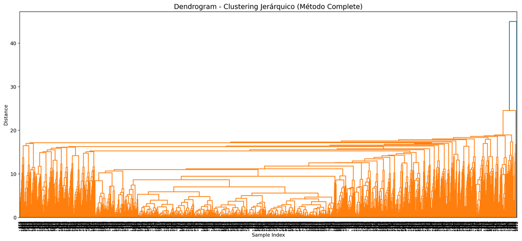

```python
pipeline_hac = Pipeline([
    ('scaler', StandardScaler()),
    ('agglo', AgglomerativeClustering(n_clusters=3))
])

labels_hac = pipeline_hac.fit_predict(X_combined)
df_processed['cluster_hac'] = labels_hac

X_scaled = pipeline_hac.named_steps['scaler'].transform(X_combined)
linked = linkage(X_scaled, method='complete')

plt.figure(figsize=(15, 7))
dendrogram(linked, orientation='top', distance_sort='descending', show_leaf_counts=True, leaf_font_size=8)
plt.title("Dendrogram - Clustering Jerárquico (Método Complete)", fontsize=14)
plt.xlabel("Sample Index")
plt.ylabel("Distance")
plt.tight_layout()
plt.show()
```

### VISUALIZACION DE DISPERSION PARA ESTE CLUSTERING

```python
X_scaled = pipeline_hac.named_steps['scaler'].transform(X_combined)

df_viz = pd.DataFrame({
    'authorFollowers': X_scaled[:, 0],
    'account_age_days': X_scaled[:, 1],
    'clusters': labels_hac.astype(str),
    'index': df_processed.index.astype(str)
})

scatter = alt.Chart(df_viz).mark_circle(size=65).encode(
    alt.X('authorFollowers:Q', title='AuthorFollowers (escalado)'),
    alt.Y('account_age_days:Q', title='Account Age Days (escalado)'),
    alt.Color('clusters:N', title='Cluster'),
    tooltip=['authorFollowers', 'account_age_days', 'index', 'clusters']
).interactive()

texto_scatter = alt.Chart(df_viz).mark_text(
    align='left',
    dx=5,
    baseline='middle',
    fontSize=8
).encode(
    alt.X('authorFollowers:Q'),
    alt.Y('account_age_days:Q'),
    text='index'
)

(scatter + texto_scatter).properties(
    width=500,
    height=500,
    title='Clustering Jerárquico - Seguidores vs Edad Cuenta'
)

print("\n" + "=" * 70)
print("ANÁLISIS DE CLUSTERS HAC")
print("=" * 70)

for cluster_id in range(3):
    cluster_data = df_processed[df_processed['cluster_hac'] == cluster_id]
    print(f"\nClúster {cluster_id} (n={len(cluster_data)}):")
    print(f"  - Seguidores promedio: {cluster_data['authorFollowers'].mean():.0f}")
    print(f"  - Edad cuenta (días): {cluster_data['account_age_days'].mean():.0f}")
    print(f"  - Menciones por tweet: {cluster_data['mentions_count'].mean():.2f}")
    print(f"  - Toxicidad promedio: {cluster_data['toxicity_score'].mean():.3f}")
```

```
======================================================================
ANÁLISIS DE CLUSTERS HAC
======================================================================

Clúster 0 (n=1077):
  - Seguidores promedio: 4936
  - Edad cuenta (días): 2265
  - Menciones por tweet: 1.69
  - Toxicidad promedio: 0.277

Clúster 1 (n=29):
  - Seguidores promedio: 184
  - Edad cuenta (días): 2381
  - Menciones por tweet: 3.52
  - Toxicidad promedio: 0.297

Clúster 2 (n=394):
  - Seguidores promedio: 298
  - Edad cuenta (días): 2279
  - Menciones por tweet: 1.69
  - Toxicidad promedio: 0.186
```

```python
scatter + texto_scatter
```

[interactive chart not shown]

### IMPRIMIMOS DETALLES SOBRELOS DATOSDE ESTE CLUSTERING COMO SEGUIDORES

### Y VEMOS QUE HAY 3 GRUPOS UNO CON MUCHAS PERSONAS,Y OTROS CON POCAS,

### AL PARECER ESTOS 2 GRUPOS TIENEN LA MAYOR Y MENOR CANTIDAD DE TOXICIDAD

### PODRIA SER UN INDICADOR DE BOTS

```python
X_scaled = pipeline_hac.named_steps['scaler'].transform(X_combined)

df_viz = pd.DataFrame({
    'authorFollowers': X_scaled[:, 0],
    'account_age_days': X_scaled[:, 1],
    'clusters': labels_hac.astype(str),
    'index': df_processed.index.astype(str)
})

scatter = alt.Chart(df_viz).mark_circle(size=65).encode(
    alt.X('authorFollowers:Q', title='AuthorFollowers (escalado)'),
    alt.Y('account_age_days:Q', title='Account Age Days (escalado)'),
    alt.Color('clusters:N', title='Cluster'),
    tooltip=['authorFollowers', 'account_age_days', 'index', 'clusters']
).interactive()

texto_scatter = alt.Chart(df_viz).mark_text(
    align='left',
    dx=5,
    baseline='middle',
    fontSize=8
).encode(
    alt.X('authorFollowers:Q'),
    alt.Y('account_age_days:Q'),
    text='index'
)

(scatter + texto_scatter).properties(
    width=500,
    height=500,
    title='Clustering Jerárquico - Seguidores vs Edad Cuenta'
)

scatter + texto_scatter

print("\n" + "=" * 70)
print("ANÁLISIS DE CLUSTERS HAC")
print("=" * 70)

for cluster_id in range(3):
    cluster_data = df_processed[df_processed['cluster_hac'] == cluster_id]
    print(f"\nClúster {cluster_id} (n={len(cluster_data)}):")
    print(f"  - Seguidores promedio: {cluster_data['authorFollowers'].mean():.0f}")
    print(f"  - Edad cuenta (días): {cluster_data['account_age_days'].mean():.0f}")
    print(f"  - Menciones por tweet: {cluster_data['mentions_count'].mean():.2f}")
    print(f"  - Toxicidad promedio: {cluster_data['toxicity_score'].mean():.3f}")
```

```
======================================================================
ANÁLISIS DE CLUSTERS HAC
======================================================================

Clúster 0 (n=1077):
  - Seguidores promedio: 4936
  - Edad cuenta (días): 2265
  - Menciones por tweet: 1.69
  - Toxicidad promedio: 0.277

Clúster 1 (n=29):
  - Seguidores promedio: 184
  - Edad cuenta (días): 2381
  - Menciones por tweet: 3.52
  - Toxicidad promedio: 0.297

Clúster 2 (n=394):
  - Seguidores promedio: 298
  - Edad cuenta (días): 2279
  - Menciones por tweet: 1.69
  - Toxicidad promedio: 0.186
```

# AHORA QUE YA HEMOS EJECUTADO ESTOS MODELOS EL DATAFRAME TIENE MAS INFORMACION ESTO ES DE GRAN IMPORTANCIA PARA LOS SIGUIENTES MODELOS

### Definicion de PIPELINES,COLUMN TRANSFORM Y DIVISION DE DATOS

```python
toxicity_threshold = df_processed['toxicity_score'].median()
y_binary = (df_processed['toxicity_score'] > toxicity_threshold).astype(int)

cols_drop = ['toxicity_score', 'content_cleaned', 'content', 'authorName', 'authorUsername']
cols_drop = [col for col in cols_drop if col in df_processed.columns]
X = df_processed.drop(cols_drop, axis=1)

nominal_cols = [col for col in categorical_filtered if col in X.columns]
numeric_cols = [col for col in behavior_features if col in X.columns]

nominal_pipeline = Pipeline([
    ('imputacion_nom', SimpleImputer(strategy='most_frequent')),
    ('encodage_nom', OneHotEncoder(handle_unknown='ignore', sparse_output=False))
])

numeric_pipeline = Pipeline([
    ('imputacion_num', SimpleImputer(strategy='median')),
    ('escalamiento', StandardScaler())
])

preprocessor = ColumnTransformer([
    ('nom', nominal_pipeline, nominal_cols),
    ('num', numeric_pipeline, numeric_cols)
], remainder='drop')

X_train, X_test, y_train, y_test = train_test_split(
    X, y_binary, test_size=0.2, stratify=y_binary, random_state=42
)

pipeline_knn = Pipeline([
    ('preprocessor', preprocessor),
    ('clasificador', KNeighborsClassifier())
])
```

### PRIMERO SE PROBARA EL MODELO KNN CON GRIDSEARCH PARA USO DE HIPERPARAMETROS

```python
param_grid_knn = {
    'clasificador__n_neighbors': [3, 5, 7, 9, 11],
    'clasificador__weights': ['uniform', 'distance'],
    'clasificador__metric': ['euclidean', 'manhattan']
}

grid_knn = GridSearchCV(
    pipeline_knn,
    param_grid_knn,
    cv=5,
    scoring='f1_weighted',
    n_jobs=1,
    verbose=1
)

grid_knn.fit(X_train, y_train)
best_model_knn = grid_knn.best_estimator_
y_pred_knn = best_model_knn.predict(X_test)
```

```
Fitting 5 folds for each of 20 candidates, totalling 100 fits
```

```python
print("=" * 70)
print("KNN - MEJORES PARÁMETROS Y EVALUACIÓN")
print("=" * 70)
print(grid_knn.best_params_)
print(f"\nMejor puntuación CV: {grid_knn.best_score_:.4f}")
print(f"Accuracy en test: {best_model_knn.score(X_test, y_test):.4f}")
print("\nReporte de Clasificación:")
print(classification_report(y_test, y_pred_knn, target_names=['Toxicidad Baja', 'Toxicidad Alta']))
```

```
======================================================================
KNN - MEJORES PARÁMETROS Y EVALUACIÓN
======================================================================
{'clasificador__metric': 'euclidean', 'clasificador__n_neighbors': 3, 'clasificador__weights': 'uniform'}

Mejor puntuación CV: 0.5912
Accuracy en test: 0.5967

Reporte de Clasificación:
                precision    recall  f1-score   support

Toxicidad Baja       0.59      0.64      0.61       150
Toxicidad Alta       0.61      0.55      0.58       150

      accuracy                           0.60       300
     macro avg       0.60      0.60      0.60       300
  weighted avg       0.60      0.60      0.60       300
```

### MATRIZ DE CONFUCION PARA KNN

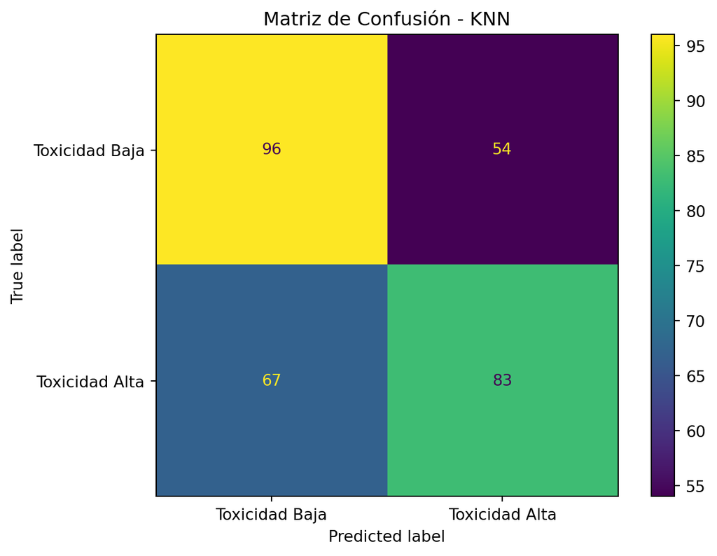

```python
plt.figure(figsize=(8, 6))
ConfusionMatrixDisplay(
    confusion_matrix(y_test, y_pred_knn),
    display_labels=['Toxicidad Baja', 'Toxicidad Alta']
).plot()
plt.title('Matriz de Confusión - KNN')
plt.tight_layout()
plt.show()
```

# DEFINICION DE MODELOS RANDOM Y GRADIENT PARA CLASIFICACION

```python
modelos = {
    'Random Forest': Pipeline([
        ('preprocessor', preprocessor),
        ('clasificador', RandomForestClassifier(n_estimators=100, random_state=42, n_jobs=-1))
    ]),
    'Gradient Boosting': Pipeline([
        ('preprocessor', preprocessor),
        ('clasificador', GradientBoostingClassifier(n_estimators=100, random_state=42))
    ])
}
```

# ENTRENAMIENTO Y EVALUACIÓN

```python
resultados = {}
predicciones = {}

print("\n" + "=" * 70)
print("ENTRENAMIENTO Y EVALUACIÓN DE MODELOS")
print("=" * 70)

for nombre_modelo, modelo in modelos.items():
    print(f"\nModelo: {nombre_modelo}")
    modelo.fit(X_train, y_train)

    y_pred = modelo.predict(X_test)
    y_pred_proba = modelo.predict_proba(X_test)[:, 1]

    predicciones[nombre_modelo] = {'y_pred': y_pred, 'y_pred_proba': y_pred_proba}

    accuracy = accuracy_score(y_test, y_pred)
    precision = precision_score(y_test, y_pred)
    recall = recall_score(y_test, y_pred)
    f1 = f1_score(y_test, y_pred)
    roc_auc = roc_auc_score(y_test, y_pred_proba)

    resultados[nombre_modelo] = {
        'accuracy': accuracy,
        'precision': precision,
        'recall': recall,
        'f1': f1,
        'roc_auc': roc_auc
    }

    print(f"Accuracy:  {accuracy:.4f}")
    print(f"Precision: {precision:.4f}")
    print(f"Recall:    {recall:.4f}")
    print(f"F1-Score:  {f1:.4f}")
    print(f"ROC-AUC:   {roc_auc:.4f}")
    print(classification_report(y_test, y_pred, target_names=['Baja Toxicidad', 'Alta Toxicidad']))
```

```
======================================================================
ENTRENAMIENTO Y EVALUACIÓN DE MODELOS
======================================================================

Modelo: Random Forest
Accuracy:  0.6267
Precision: 0.6234
Recall:    0.6400
F1-Score:  0.6316
ROC-AUC:   0.6814
                precision    recall  f1-score   support

Baja Toxicidad       0.63      0.61      0.62       150
Alta Toxicidad       0.62      0.64      0.63       150

      accuracy                           0.63       300
     macro avg       0.63      0.63      0.63       300
  weighted avg       0.63      0.63      0.63       300


Modelo: Gradient Boosting
Accuracy:  0.6300
Precision: 0.6196
Recall:    0.6733
F1-Score:  0.6454
ROC-AUC:   0.6854
                precision    recall  f1-score   support

Baja Toxicidad       0.64      0.59      0.61       150
Alta Toxicidad       0.62      0.67      0.65       150

      accuracy                           0.63       300
     macro avg       0.63      0.63      0.63       300
  weighted avg       0.63      0.63      0.63       300
```

```python
df_resultados = pd.DataFrame(resultados).T
print("\n" + "=" * 70)
print("COMPARACIÓN DE MODELOS")
print("=" * 70)
print(df_resultados.round(4))

df_metricas = df_resultados.reset_index().melt(id_vars='index', var_name='metrica', value_name='valor')
df_metricas.rename(columns={'index': 'modelo'}, inplace=True)

heatmap = alt.Chart(df_metricas).mark_rect().encode(
    alt.X('metrica:N', title='Métrica'),
    alt.Y('modelo:N', title='Modelo'),
    alt.Color('valor:Q', scale=alt.Scale(scheme='viridis', domain=[0, 1]), title='Score'),
    tooltip=['modelo', 'metrica', alt.Tooltip('valor:Q', format='.4f')]
).properties(width=400, height=200, title='Heatmap de Métricas de Desempeño').interactive()

heatmap
```

```
======================================================================
COMPARACIÓN DE MODELOS
======================================================================
                   accuracy  precision  recall      f1  roc_auc
Random Forest        0.6267     0.6234  0.6400  0.6316   0.6814
Gradient Boosting    0.6300     0.6196  0.6733  0.6454   0.6854
```

[interactive chart not shown]

```python
roc_data = []
for nombre_modelo, preds in predicciones.items():
    y_pred_proba = preds['y_pred_proba']
    fpr, tpr, _ = roc_curve(y_test, y_pred_proba)
    roc_auc = auc(fpr, tpr)
    for fp, tp in zip(fpr, tpr):
        roc_data.append({'FPR': fp, 'TPR': tp, 'Modelo': f'{nombre_modelo} (AUC={roc_auc:.3f})'})

for i in np.linspace(0, 1, 100):
    roc_data.append({'FPR': i, 'TPR': i, 'Modelo': 'Random Classifier'})

df_roc = pd.DataFrame(roc_data)
```

```python
print("\n" + "=" * 70)
print("MATRIZ DE CONFUSIÓN - MODELO 1")
print("=" * 70)

# Obtener predicciones del primer modelo
nombre_modelo1 = list(predicciones.keys())[0]
preds1 = predicciones[nombre_modelo1]
y_pred1 = preds1['y_pred']
cm1 = confusion_matrix(y_test, y_pred1)

# Convertir matriz de confusión a formato long para Altair
cm_data1 = []
for i, label_real in enumerate(['Baja', 'Alta']):
    for j, label_pred in enumerate(['Baja', 'Alta']):
        cm_data1.append({
            'Verdadero': label_real,
            'Predicho': label_pred,
            'Cantidad': int(cm1[i, j])
        })

df_cm1 = pd.DataFrame(cm_data1)

# Crear heatmap
cm_chart1 = alt.Chart(df_cm1).mark_rect().encode(
    alt.X('Predicho:N', title='Predicho'),
    alt.Y('Verdadero:N', title='Verdadero'),
    alt.Color('Cantidad:Q', scale=alt.Scale(scheme='blues'), title='Cantidad'),
    tooltip=['Verdadero', 'Predicho', 'Cantidad']
).properties(
    width=300,
    height=300,
    title=f'Matriz de Confusión - {nombre_modelo1}'
)

# Texto con las cantidades
text1 = alt.Chart(df_cm1).mark_text(baseline='middle').encode(
    alt.X('Predicho:N'),
    alt.Y('Verdadero:N'),
    text='Cantidad:Q'
)

# Mostrar el gráfico combinado
(cm_chart1 + text1)
print(f"\nMatriz de Confusión - {nombre_modelo1}:")

(cm_chart1 + text1)
(cm_chart1 + text1)
```

```
======================================================================
MATRIZ DE CONFUSIÓN - MODELO 1
======================================================================

Matriz de Confusión - Random Forest:
```

[interactive chart not shown]

```python
print("\n" + "=" * 70)
print("MODELO 2")
print("=" * 70)

# Obtener predicciones del segundo modelo
nombre_modelo2 = list(predicciones.keys())[1]
preds2 = predicciones[nombre_modelo2]
y_pred2 = preds2['y_pred']
cm2 = confusion_matrix(y_test, y_pred2)

# Convertir matriz de confusión a formato long para Altair
cm_data2 = []
for i, label_real in enumerate(['Baja', 'Alta']):
    for j, label_pred in enumerate(['Baja', 'Alta']):
        cm_data2.append({
            'Verdadero': label_real,
            'Predicho': label_pred,
            'Cantidad': int(cm2[i, j])
        })

df_cm2 = pd.DataFrame(cm_data2)

# Crear heatmap
cm_chart2 = alt.Chart(df_cm2).mark_rect().encode(
    alt.X('Predicho:N', title='Predicho'),
    alt.Y('Verdadero:N', title='Verdadero'),
    alt.Color('Cantidad:Q', scale=alt.Scale(scheme='blues'), title='Cantidad'),
    tooltip=['Verdadero', 'Predicho', 'Cantidad']
).properties(
    width=300,
    height=300,
    title=f'Matriz de Confusión - {nombre_modelo2}'
)

# Texto con las cantidades
text2 = alt.Chart(df_cm2).mark_text(baseline='middle').encode(
    alt.X('Predicho:N'),
    alt.Y('Verdadero:N'),
    text='Cantidad:Q'
)

# Mostrar el gráfico combinado
(cm_chart2 + text2)
print(f"\nMatriz de Confusión - {nombre_modelo2}:")
(cm_chart2 + text2)

(cm_chart2 + text2)
```

```
======================================================================
MODELO 2
======================================================================

Matriz de Confusión - Gradient Boosting:
```

[interactive chart not shown]

### CURVA ROC PARA AMBOS MODELOS, AMBOS SE DESEMPEÑAN BIEN DANDO VALORES MAYORES QUE LA MEDIA

```python
roc_chart = alt.Chart(df_roc).mark_line(point=True).encode(
    alt.X('FPR:Q', title='False Positive Rate', scale=alt.Scale(domain=[0, 1])),
    alt.Y('TPR:Q', title='True Positive Rate', scale=alt.Scale(domain=[0, 1])),
    alt.Color('Modelo:N', title='Modelo'),
    tooltip=['FPR', 'TPR', 'Modelo']
).properties(width=500, height=400, title='Curva ROC - Comparación de Modelos').interactive()

roc_chart
```

[interactive chart not shown]

```python
print("\n" + "=" * 70)
print("RESUMEN FINAL")
print("=" * 70)
print(f"Mejor modelo por ROC-AUC: {df_resultados['roc_auc'].idxmax()}")
print(f"  ROC-AUC: {df_resultados['roc_auc'].max():.4f}")
print(f"Mejor modelo por F1-Score: {df_resultados['f1'].idxmax()}")
print(f"  F1-Score: {df_resultados['f1'].max():.4f}")
```

```
======================================================================
RESUMEN FINAL
======================================================================
Mejor modelo por ROC-AUC: Gradient Boosting
  ROC-AUC: 0.6854
Mejor modelo por F1-Score: Gradient Boosting
  F1-Score: 0.6454
```

# MODELOS DE REGRESION

### SE USARA LINEAL REGRESION Y ARBOLES DE DECISION

```python
import pandas as pd
import numpy as np
import altair as alt
from sklearn.model_selection import train_test_split, cross_val_score, GridSearchCV
from sklearn.preprocessing import StandardScaler, OneHotEncoder
from sklearn.impute import SimpleImputer
from sklearn.compose import ColumnTransformer
from sklearn.pipeline import Pipeline
from sklearn.linear_model import LinearRegression
from sklearn.tree import DecisionTreeRegressor
from sklearn.metrics import mean_squared_error, r2_score, mean_absolute_error
import warnings
warnings.filterwarnings('ignore')
```

```python
y = df_processed['toxicity_score']

print(f"Registros totales: {len(df_processed)}")
print(f"NaN en toxicity_score: {y.isna().sum()}\n")

# Definir features a eliminar
cols_drop = ['toxicity_score', 'content_cleaned', 'content', 'authorName', 'authorUsername']
cols_drop = [col for col in cols_drop if col in df_processed.columns]
X = df_processed.drop(cols_drop, axis=1)

# Separar columnas nominales y numéricas
nominal_cols = [col for col in categorical_filtered if col in X.columns]
numeric_cols = [col for col in behavior_features if col in X.columns]

print(f"Variables nominales: {len(nominal_cols)}")
print(f"Variables numéricas: {len(numeric_cols)}")
print(f"Total features: {X.shape[1]}\n")
```

```
Registros totales: 1500
NaN en toxicity_score: 0

Variables nominales: 6
Variables numéricas: 8
Total features: 23
```

```python
print(f"Tamaño entrenamiento: {X_train.shape}")
print(f"Tamaño prueba: {X_test.shape}\n")
```

```
Tamaño entrenamiento: (1200, 23)
Tamaño prueba: (300, 23)
```

```python
print("="*70)
print("REGRESIÓN LINEAL")
print("="*70)

pipeline_lr = Pipeline([
    ('preprocessor', preprocessor),
    ('modelo', LinearRegression())
])

# Entrenar
pipeline_lr.fit(X_train, y_train)

# Predicciones
y_pred_lr_train = pipeline_lr.predict(X_train)
y_pred_lr_test = pipeline_lr.predict(X_test)

# Métricas
mse_lr_train = mean_squared_error(y_train, y_pred_lr_train)
mse_lr_test = mean_squared_error(y_test, y_pred_lr_test)
rmse_lr_train = np.sqrt(mse_lr_train)
rmse_lr_test = np.sqrt(mse_lr_test)
mae_lr_test = mean_absolute_error(y_test, y_pred_lr_test)
r2_lr_train = r2_score(y_train, y_pred_lr_train)
r2_lr_test = r2_score(y_test, y_pred_lr_test)

print(f"Entrenamiento - RMSE: {rmse_lr_train:.4f}, R²: {r2_lr_train:.4f}")
print(f"Prueba        - RMSE: {rmse_lr_test:.4f}, R²: {r2_lr_test:.4f}")
print(f"MAE (Prueba)  : {mae_lr_test:.4f}\n")
```

```
======================================================================
REGRESIÓN LINEAL
======================================================================
Entrenamiento - RMSE: 0.0000, R²: 1.0000
Prueba        - RMSE: 0.4967, R²: 0.0132
MAE (Prueba)  : 0.4546
```

```python
print("="*70)
print("ÁRBOL DE DECISIÓN - BÚSQUEDA DE HIPERPARÁMETROS")
print("="*70)

pipeline_dt_base = Pipeline([
    ('preprocessor', preprocessor),
    ('modelo', DecisionTreeRegressor(random_state=42))
])


param_grid = {
    'modelo__max_depth': [5, 10, 15, 20, None],
    'modelo__min_samples_split': [2, 5, 10, 20],
    'modelo__min_samples_leaf': [1, 2, 4, 8]
}

grid_search = GridSearchCV(
    pipeline_dt_base,
    param_grid,
    cv=5,
    scoring='r2',
    n_jobs=1,
    verbose=0
)

grid_search.fit(X_train, y_train)

print(f"Mejores parámetros: {grid_search.best_params_}")
print(f"Mejor R² (CV): {grid_search.best_score_:.4f}\n")

# Modelo óptimo
pipeline_dt = grid_search.best_estimator_

# Predicciones
y_pred_dt_train = pipeline_dt.predict(X_train)
y_pred_dt_test = pipeline_dt.predict(X_test)

# Métricas
mse_dt_train = mean_squared_error(y_train, y_pred_dt_train)
mse_dt_test = mean_squared_error(y_test, y_pred_dt_test)
rmse_dt_train = np.sqrt(mse_dt_train)
rmse_dt_test = np.sqrt(mse_dt_test)
mae_dt_test = mean_absolute_error(y_test, y_pred_dt_test)
r2_dt_train = r2_score(y_train, y_pred_dt_train)
r2_dt_test = r2_score(y_test, y_pred_dt_test)

print("="*70)
print("ÁRBOL DE DECISIÓN - RESULTADOS FINALES")
print("="*70)
print(f"Entrenamiento - RMSE: {rmse_dt_train:.4f}, R²: {r2_dt_train:.4f}")
print(f"Prueba        - RMSE: {rmse_dt_test:.4f}, R²: {r2_dt_test:.4f}")
print(f"MAE (Prueba)  : {mae_dt_test:.4f}\n")
```

```
======================================================================
ÁRBOL DE DECISIÓN - BÚSQUEDA DE HIPERPARÁMETROS
======================================================================
Mejores parámetros: {'modelo__max_depth': 5, 'modelo__min_samples_leaf': 8, 'modelo__min_samples_split': 20}
Mejor R² (CV): -0.0044

======================================================================
ÁRBOL DE DECISIÓN - RESULTADOS FINALES
======================================================================
Entrenamiento - RMSE: 0.4541, R²: 0.1751
Prueba        - RMSE: 0.4951, R²: 0.0195
MAE (Prueba)  : 0.4477
```

```python
print("="*70)
print("COMPARACIÓN DE MODELOS")
print("="*70)

comparison_df = pd.DataFrame({
    'Modelo': ['Regresión Lineal', 'Árbol de Decisión'],
    'RMSE Entrenamiento': [rmse_lr_train, rmse_dt_train],
    'RMSE Prueba': [rmse_lr_test, rmse_dt_test],
    'R² Entrenamiento': [r2_lr_train, r2_dt_train],
    'R² Prueba': [r2_lr_test, r2_dt_test],
    'MAE Prueba': [mae_lr_test, mae_dt_test]
})

print(comparison_df.to_string(index=False))
print()



df_lr_pred = pd.DataFrame({
    'Real': y_test.values,
    'Predicción': y_pred_lr_test,
    'Modelo': 'Regresión Lineal'
})

df_dt_pred = pd.DataFrame({
    'Real': y_test.values,
    'Predicción': y_pred_dt_test,
    'Modelo': 'Árbol de Decisión'
})

df_predicciones = pd.concat([df_lr_pred, df_dt_pred], ignore_index=True)
```

```
======================================================================
COMPARACIÓN DE MODELOS
======================================================================
           Modelo  RMSE Entrenamiento  RMSE Prueba  R² Entrenamiento  R² Prueba  MAE Prueba
 Regresión Lineal        4.871027e-15     0.496683          1.000000   0.013223    0.454584
Árbol de Decisión        4.541123e-01     0.495107          0.175128   0.019476    0.447703
```

```python
# Crear DataFrames para visualización
df_lr_pred = pd.DataFrame({
    'Real': y_test.values,
    'Predicción': y_pred_lr_test,
    'Modelo': 'Regresión Lineal',
    'Error': np.abs(y_test.values - y_pred_lr_test)
})

df_dt_pred = pd.DataFrame({
    'Real': y_test.values,
    'Predicción': y_pred_dt_test,
    'Modelo': 'Árbol de Decisión',
    'Error': np.abs(y_test.values - y_pred_dt_test)
})

df_predicciones = pd.concat([df_lr_pred, df_dt_pred], ignore_index=True)

# Calcular límites con padding
min_val = df_predicciones[['Real', 'Predicción']].min().min()
max_val = df_predicciones[['Real', 'Predicción']].max().max()
padding = (max_val - min_val) * 0.05

# Selector interactivo
brush = alt.selection_interval()

base = alt.Chart(df_predicciones).properties(
    width=300,
    height=300
)

# Scatter plot con interactividad
scatter = base.mark_circle(
    size=60
).encode(
    x=alt.X('Real:Q',
            title='Valor Real de Toxicity Score',
            scale=alt.Scale(domain=[min_val - padding, max_val + padding])),
    y=alt.Y('Predicción:Q',
            title='Valor Predicho de Toxicity Score',
            scale=alt.Scale(domain=[min_val - padding, max_val + padding])),
    color=alt.condition(
        brush,
        alt.Color('Modelo:N', legend=None, scale=alt.Scale(scheme='set1')),
        alt.value('lightgray')
    ),
    opacity=alt.condition(brush, alt.value(0.8), alt.value(0.2)),
    tooltip=[
        alt.Tooltip('Real:Q', format='.4f'),
        alt.Tooltip('Predicción:Q', format='.4f'),
        alt.Tooltip('Error:Q', format='.4f'),
        'Modelo:N'
    ]
).add_params(
    brush
)

# Línea de referencia diagonal
line = base.mark_line(
    color='red',
    strokeDash=[5, 5],
    strokeWidth=2
).encode(
    x='Real:Q',
    y='Real:Q'
)

# Combinar y hacer facet con zoom interactivo
chart_combinado = (scatter + line).facet(
    column='Modelo:N'
).properties(
    title='Comparación: Predicciones vs Valores Reales - Modelos de Regresión (Interactivo)'
).interactive()

chart_combinado
```

[interactive chart not shown]

### GRAFICO DE ERRORES RESIDUALES

```python
# Calcular residuales
df_residuales_lr = pd.DataFrame({
    'Predicción': y_pred_lr_test,
    'Residual': y_test.values - y_pred_lr_test,
    'Modelo': 'Regresión Lineal'
})

df_residuales_dt = pd.DataFrame({
    'Predicción': y_pred_dt_test,
    'Residual': y_test.values - y_pred_dt_test,
    'Modelo': 'Árbol de Decisión'
})

df_residuales = pd.concat([df_residuales_lr, df_residuales_dt], ignore_index=True)


chart_residuales = alt.Chart(df_residuales).mark_circle(
    opacity=0.6,
    size=60
).encode(
    x=alt.X('Predicción:Q',
            title='Valores Predichos',
            scale=alt.Scale(zero=False)),
    y=alt.Y('Residual:Q',
            title='Residuales (Real - Predicho)',
            scale=alt.Scale(zero=False)),
    color=alt.Color('Modelo:N',
                   legend=None,
                   scale=alt.Scale(scheme='set1')),
    tooltip=['Predicción', 'Residual', 'Modelo']
).properties(
    width=300,
    height=300
)


linea_cero = alt.Chart(df_residuales).mark_rule(
    color='red',
    strokeDash=[5, 5],
    strokeWidth=2
).encode(
    y=alt.datum(0)
)


chart_residuales_final = (chart_residuales + linea_cero).facet(
    column='Modelo:N'
).properties(
    title='Análisis de Residuales por Modelo'
)

chart_residuales_final
```

[interactive chart not shown]

```python
df_metricas = pd.DataFrame({
    'Métrica': ['RMSE Entrenamiento', 'RMSE Prueba', 'R² Entrenamiento', 'R² Prueba'],
    'Regresión Lineal': [rmse_lr_train, rmse_lr_test, r2_lr_train, r2_lr_test],
    'Árbol de Decisión': [rmse_dt_train, rmse_dt_test, r2_dt_train, r2_dt_test]
})

df_metricas_long = df_metricas.melt(id_vars='Métrica', var_name='Modelo', value_name='Valor')

chart_metricas = alt.Chart(df_metricas_long).mark_bar().encode(
    alt.X('Métrica:N', title='Métrica'),
    alt.Y('Valor:Q', title='Valor'),
    color=alt.Color('Modelo:N', scale=alt.Scale(scheme='category10')),
    xOffset='Modelo:N',
    tooltip=['Métrica', 'Modelo', 'Valor']
).properties(
    width=600,
    height=300,
    title='Comparación de Métricas de Desempeño'
)

chart_metricas.display()
```

[interactive chart not shown]

```python
# Obtener nombres de features después del preprocesamiento
dt_model = pipeline_dt.named_steps['modelo']
preprocessor = pipeline_dt.named_steps['preprocessor']

# Obtener feature names
feature_names = []
for name, transformer, cols in preprocessor.transformers_:
    if name == 'nom':
        encoder = transformer.named_steps['encodage_nom']
        feature_names.extend(encoder.get_feature_names_out(cols))
    elif name == 'num':
        feature_names.extend(cols)

# Importancia de variables
importances = dt_model.feature_importances_
feature_importance_df = pd.DataFrame({
    'Feature': feature_names,
    'Importance': importances
}).sort_values('Importance', ascending=False).head(15)

# Gráfico de Importancia con Altair
chart_importance = alt.Chart(feature_importance_df).mark_bar().encode(
    alt.X('Importance:Q', title='Importancia'),
    alt.Y('Feature:N', sort='-x', title='Variable'),
    color=alt.value('#2ca02c'),
    tooltip=['Feature', 'Importance']
).properties(
    width=600,
    height=400,
    title='Top 15 Variables Más Importantes - Árbol de Decisión'
)

chart_importance.display()

print("\nTop 10 Variables Más Importantes:")
print(feature_importance_df.head(10).to_string(index=False))
```

[interactive chart not shown]

```
Top 10 Variables Más Importantes:
                                                          Feature  Importance
                                                   content_length    0.392047
                                          replyTo_LuisaGonzalezEc    0.123690
                                                    time_response    0.118258
                                                  authorFollowers    0.114891
                                                diasDesdeCreacion    0.086607
                                                 account_age_days    0.073136
                                            replyTo_DanielNoboaOk    0.036840
                           mentions_@LuisaGonzalezEc, @RC5Oficial    0.035010
                                                   mentions_count    0.019521
tweetUrl_https://x.com/1bbc50531675403/status/1904563745919054260    0.000000
```

### - Hay patrones muy interesantes en Hac hay un patron de toxicidad aparentemente donde se

### identificaron 3 grupos uno con la mayoria de personas en el con una toxicidad normal y 2 grupos

### con alta y otro grupo con baja toxicidad

### Probar con mas datos, imputar con otras alternativas usar la mediana y la moda probar otros modelos para ver como rinden .

#### -Probar el modelo en toxicidad de nuevos tweets

### -Quizas crear una Api para prediccion de bots basados en toxicidad,